# Combining Rapid Antigen Testing and Syndromic Data Improves Sensitivity and Specificity in Real-World COVID-19 Detection

Fergus J Chadwick

IBAHCM,UoGLMICS  
f.chadwick.1@research.gla.ac.uk

Yacob Haddou

IBAHCM,UoGLMICS  
yacob.haddou@glasgow.ac.uk

Tasnuva Chowdhury

IBAHCM  
tasnuvachowdhury2004@gmail.com

David Pascall

MRCB  
david.pascall@mrc-bsu.cam.ac.uk

Shayan Chowdhury

a2i  
shayan.chowdhury@a2i.gov.bd

Jessica Clark

IBAHCM,UoGLMICS  
Jessica.Clark@glasgow.ac.uk

Joanna Andrecka

UNFAO  
aandrecka@gmail.com

Mikolaj Kundergorski

MathsandStatGla,UoGLMICS  
mikolaj.kundegorski@gmail.com

Craig Wilkie

MathsandStatGla,UoGLMICS  
craig.wilkie@glasgow.ac.uk

Eric Brum

UNFAO  
eric.brum@fao.org

Tahmina Shirin

IEDCR  
tahmina.shirin14@gmail.com

A S M Alamgir

IEDCR  
aalamgir@gmail.com

Mahbubur Rahman

IEDCR  
dr_mahbub@yahoo.com

Ahmed Nawsher Alam

IEDCR  
anawsher@yahoo.com

Farzana Khan

IEDCR  
farzanakhan_25@yahoo.com

Janine Illian

MathsandStatGla,UoGLMICS  
janine.illian@glasgow.ac.uk

Ben Swallow

MathsandStatGla,UoGLMICS  
ben.swallow@glasgow.ac.uk

Davina L Hill

IBAHCM,UoGLMICS  
davina.hill@glasgow.ac.uk

Dirk Husmeier

MathsandStatGla  
dirk.husmeier@glasgow.ac.uk

Jason Matthiopoulos

IBAHCM,UoGLMICS  
jason.matthiopoulos@glasgow.ac.uk

Katie Hampson

IBAHCM,UoGLMICS  
katie.hampson@glasgow.ac.uk

Ayesha Sania

Columbia  
ays328@mail.harvard.edu

```
## here() starts at /Users/fergusjchadwick/Dropbox/Git/COVID19_SyndromicRATDiagnosis
```

# Abstract

*Background*

The majority of the world’s population live in low- and middle-income countries where access to gold-standard diagnostics like RT-PCR is often limited. Rapid Antigen Testing (RAT) and syndromic diagnosis are two alternative, inexpensive and easy-to-deploy surveillance methods but there are concerns that they lack the sensitivity and specificity to effectively guide practice.

*Methods*

Bangladesh’s Institute of Epidemiology Disease Control And Research (IEDCR) identified potential COVID-19 patients in Dhaka using syndromic surveillance. A sample (n = 511) of these patients was tested using RAT and syndromic data were collected. Models were fit to predict RT-PCR status using the RAT data, the syndromic data, and the two combined. Model performance was measured using predictive power, sensitivity and specificity.

*Findings*

We demonstrate that integrating these imperfect data sources greatly improves the detection of COVID-19. Low-cost and accessible surveillance methods make pandemic control in low- and middle- income countries a possibility.

*Funding*

The Bill and Melinda Gates Foundation and the Wellcome Trust.

# Introduction

Identification and isolation of COVID-19 cases remains key to the pandemic response across the globe. The faster and more accurately we can identify cases, the more effectively we can provide clinical care, reduce transmission of infection and develop population-level interventions. RT-PCR testing has rapidly become the default, gold-standard test for COVID-19 in applied settings due to its high sensitivity and specificity for COVID-19 Tahamtan and Ardebili (2020). Most of the world’s population, however, live in low- and middle-income countries where the laboratory facilities needed to carry out RT-PCR tests are often scarce and hard to reach Vandenberg et al. (2021). COVID-19 diagnosis worldwide, therefore, must be made accessible using inexpensive methods that can be carried out locally Olalekan et al. (2020).

An increasingly popular alternative to RT-PCR is rapid antigen testing (RAT) (Linares et al. 2020). Like RT-PCR, these tests have high specificity for COVID-19 while being less expensive, easier to implement, and faster to produce results (Boum et al. 2021). RATs also require less commitment and discomfort for patients. For RT-PCR testing, patients must travel to a designated site (such as a hospital or testing booth) or have highly visible PPE-clad officials visit their home. Then, invasive nasopharyngeal swabs must be taken and there is a delay in receiving the result (between one day and a week in Bangladesh). In contract, RAT can be conducted on nasal or saliva samples, completed in the home and results are available in 30 minutes. RATs can be taken by persons with limited training, thus decreasing the time and expense associated with identifying cases. Together, these traits make RATs an appealing alternative to RT-PCR. However, several concerns have been raised about the sensitivity of RAT (Mak et al. 2020, muhi2021multi) leading to more false negative diagnoses.

Another alternative to RT-PCR, one that has been used since the start of the pandemic, is identifying cases through symptom-thresholding (Jin et al. 2020). In this approach, a patient presenting with a fever and one or more viral pneumonia symptoms is treated as a COVID-19 positive patient. The main advantage of this approach is the ease of implementation. For example, in Bangladesh, a lower middle-income country, much of the initial support and reporting of infections locally is provided by community support teams (CSTs) composed of local volunteers with basic training. The CSTs can easily collect symptomatic data in the community and provide care where the criteria are met. Unfortunately, these symptom-thresholds were developed early in the outbreak, and thus necessarily drawn from clinical intuition, rather than data. Consequently, the relationship between the criteria and the true COVID-19 status is often weak, with low specificity leading to a very large number of false positive diagnoses.

A natural extension to these symptom-threshold approaches is syndromic modelling. Here, a patient presenting with a fever and one or more viral pneumonia symptoms is treated as a potential COVID-19 patient. However, rather than using a set of pre-determined criteria, a range of symptomatic and risk factor data are collected and then a sub-sample of patients are tested using RT-PCR for COVID-19 (Sim et al. 2021). These data are used to fit a model that allows more accurate prediction of how likely a patient is to have COVID-19 through the identification of COVID-19 syndromes Wenham, Smith, and Morgan (2020). It is worth highlighting at this point that in resource-limited settings, there is very limited provision for testing of asymptomatic cases, despite their important role in disease transmission (Mayorga et al. 2020). Even while focusing solely on symptomatic patients, syndromic modelling is a complex and nuanced task. The strength of relationships between symptoms and diseases is not stable through time or across sampling strategies since the relative importance of each symptom for disease diagnosis, in part, depends on the prevalence of other diseases causing similar symptoms in the community (Garry et al. 2020). For example, if another disease for which loss of smell is a symptom becomes common, that symptom becomes a worse predictor for COVID-19. Similarly, if everyone who presents has a cough and thus is included in the sample, then coughing will likely have a very low correlation with COVID-19 (even if the two are strongly related in the general population). While these issues can be overcome by properly considering the population sampled and using appropriately sophisticated statistical methods, the many types of common respiratory disease generally means that even then these models tend to have relatively high false positive rates (low specificity) for COVID-19 (Garry et al. 2020), although much lower than the symptom-threshold approach.

Poor sensitivity and specificity are problematic in diagnositics but higher error rates may be tolerable depending on their scale and impact given the local situation. Low specificity means a large number of false positive classifications, where the patient is told they have COVID-19 but they actually do not. This might lead to patients unnecessarily self-isolating and receiving support which can be expensive to the individuals and local public health bodies, as well as reducing available resources for those who need them (Surkova, Nikolayevskyy, and Drobniewski 2020). Similarly, low sensitivity means more false negative classifications, where the patient is told they do not have COVID-19 but they actually do, which can lead to a health-risk for the individual and to the disease spreading further (West, Montori, and Sampathkumar 2020). The costs of these misclassifications will depend on local context. When the prevalence of the disease is low, false positives may create local skepticism about the value of testing, or when there are strong population-level mitigations already in place (such as a nationwide lockdown), then false positives might be more costly than false negatives (Surkova, Nikolayevskyy, and Drobniewski 2020). If the disease is abundant or increasing rapidly then false negatives are likely to be more costly. In most situations, a balance will need to be struck (Vandenberg et al. 2021).

The two dominant “alternative” testing methods available in resource limited settings, therefore, are both flawed. Relying solely on symptomatic diagnosis will likely overestimate the number of individuals with COVID-19 due to its lack of specificity. Conversely, RATs will give a false impression of control due to the number of positive cases that will be missed. In this paper, we demonstrate how to combine these data types to exploit their complementarity and ameliolariate their respective weaknesses. We aim to compare the performance of these two testing methods and the combined approach both in terms of general prediction and as diagnostics under three epidemiological scenarios; and to demonstrate that the combined data achieve equal to much lower error rates than the next best method. We then discuss the role of statistically integrating data from multiple imperfect testing methods in resource limited settings to improve the diagnosis of diseases, particularly COVID-19.

# Methods

Participants included in this study were identified for COVID-19 testing after self-reporting symptoms to the Bangladesh government’s national hotlines for COVID-19 support. Recruitment took place across Dhaka (the capital city of Bangladesh) between 2nd April 2021 and 5th May 2021.

Patients were selected for further testing conditional on the presence of a fever (>38°C) at the point of testing and one or more of 14 additional symptoms associated with COVID-19 (breathing problems, coughing, diarrhoea, fever (ongoing), a headache, loss of taste, loss of smell, muscle pain, red eyes, a runny nose, a sore throat, tiredness, vomiting or a wet cough). The patient’s age and gender were also recorded, but these data were not included in the patient selection criteria.

[figure not shown]

Schematic description of identification of likely COVID-19 patients by CSTs, swab collection and model definitions. The teams collected syndromic data (age, gender and presence/absence of 14 predetermined symptoms), and two sets of naso-pharyngeal swabs (one each for Rapid Antigen Testing and RT-PCR). We then used these two imperfect diagnostics (RAT and syndromic data) to generate three model classes: RAT result only in Model Class 1, Syndromic Data only in Model Class 2, and both RAT result and syndromic data in Model Class 3. The PCR test result is used to train and test each model using temporal cross validation.

Model Class 1 uses only the RAT result and is the simplest of the three. It simply equates a positive RAT result with the patient being PCR positive, and a negative RAT result with PCR negativity. Model Class 2 uses only the syndromic data and Model Class 3 combines the RAT result with the syndromic data.

For Model Class 2, we used a Bayesian multivariate probit model (J. H. Albert and Chib 1993). The multivariate probit structure allows the model to account for the correlations between, and binary nature of, the symptoms (e.g. loss of taste is often correlated with loss of smell). By using a Bayesian formulation, we are able to better quantify the uncertainty in the parameter estimates. Structurally, the multivariate probit model allows the symptoms and COVID-19 status to be treated as correlated binary outcomes with an intrinsic rate (the intercept for each variable) and the patient’s age and gender, while propagating and quantifying uncertainty.

In Model Class 3, we model RAT positive patients as PCR positive and use the syndromic approach outlined for Model Class 2 for the RAT negative patients. The models were fitted to the data using Hamiltonian Monte Carlo in the Stan programming language (Carpenter et al. 2017).

[figure not shown]

We then compared models as classifiers using their false positive and false negative rates in three epidemiological scenarios. In applied settings, models must often be evaluated on their performance as classifiers rather than just as prediction engines (i.e. their ability to say a patient is COVID-19 positive or negative, not simply the probability the patient might be COVID-19 positive or negative). To generate a classification, a probability threshold must be chosen over which patients are classified as COVID-19 positive.

ROC curves were drawn to show classifier performance across a range of unspecified scenarios, and error rates under three specific epidemiological scenarios were compared. ROC curves show the true and false positive rates that each model can achieve. Comparing specific scenarios allows classifier performance to be demonstrated in relevant scenarios. Whether measuring classifier performance in specific scenarios or more generally, decisions need to be made about the relative cost and acceptable levels of the two types of misclassification (false positives and negatives). We strongly emphasise that local context should be the guide in applying these methods.

In Scenario 1, we do not consider epidemiological context but simply weight false negative and false positive rates equally by aiming to maximise the overall correct classification rate. Scenario 2 corresponds to the current situation in Bangladesh at time of writing (June 2021), with COVID-19 cases beginning to rapidly increase again. Under these circumstances, false negatives are extremely costly relative to false positives due to the exponential growth of the disease. In Scenario 3, the pandemic is not declining but maintaining a steady rate of cases. In this situation, policy-makers may be keen to keep false positive diagnoses low to prevent lockdown fatigue and to keep the workforce active.

# Results

A total of 511 subjects had data available for the current analyses. The mean age of women participants (56% of the sample) was 38.5 (SD = 15.4), and for men (44% of the sample) was 41.8 (SD = 17.2). Participants were self-selecting and drawn from across Dhaka, the capital of Bangladesh.

Model selection for Model Class 2 and 3 each retained age as an explanatory variable and showed a marked decline in predictive power at more than 4 symptoms. The final four symptoms in order of importance (i.e. the most important symptom was retained in all of the final 4 models, the least important symptom was only retained in the 4 symptom model) were wet cough, runny nose, loss of smell and breathing problems for Model Class 2, and fever, wet cough, tiredness and diarrhoea for Model Class 3. For both Model Class 2 (syndromic data only) and Model Class 3 (syndromic and RAT data), model selection retained age as a covariate but not gender.

In the comparison of model predictive performance, Model Class 1 (RAT only) performed worst with a cross entropy of 4.79 (cross entropy values further from zero correspond to worse predictive performance). The median cross entropy values were between 2.90 and 2.95 for models in Class 2 (syndromic data only). Models in Class 3 (combined data model) performed best with cross entropy values between 2.40 and 2.43 (see Figure 3).

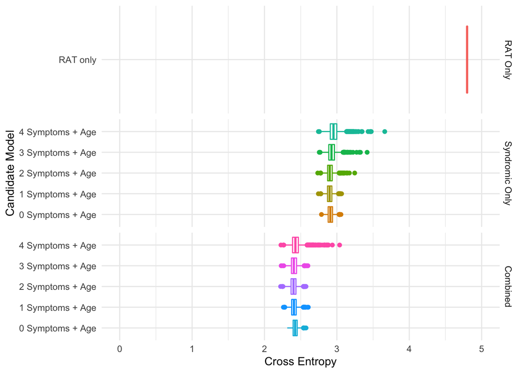

Interquartile ranges for the posterior cross entropy of the best candidate models at each level of model complexity tested under temporal cross-validation. Cross entropy is a measure of distance from the truth, so values closer to zero indicate better models. The intermediate complexity models perform best at prediction, although performance is similar across all the models within each class.

General model classification performance is shown by the full ROC curves for each model (Figure 4).

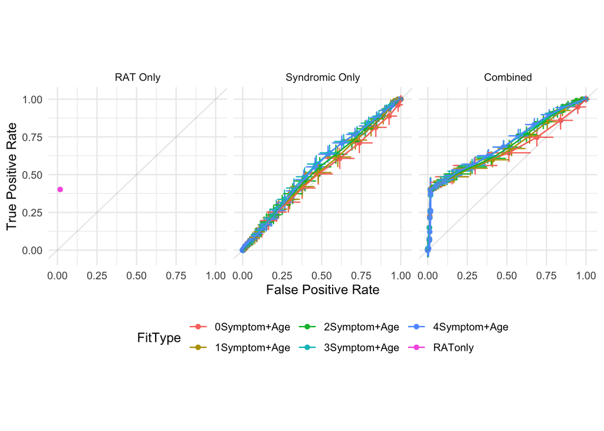

Receiver operating characteristics for RAT only approach and posterior mean (+- posterior standard deviation) receiver operating characteristics for Class 2 and 3 models. These curves demonstrate the performance of the model for any given scenario as defined by false and true positive rates (as opposed to Figure 5 which demonstrates model performance in specific scenarios).

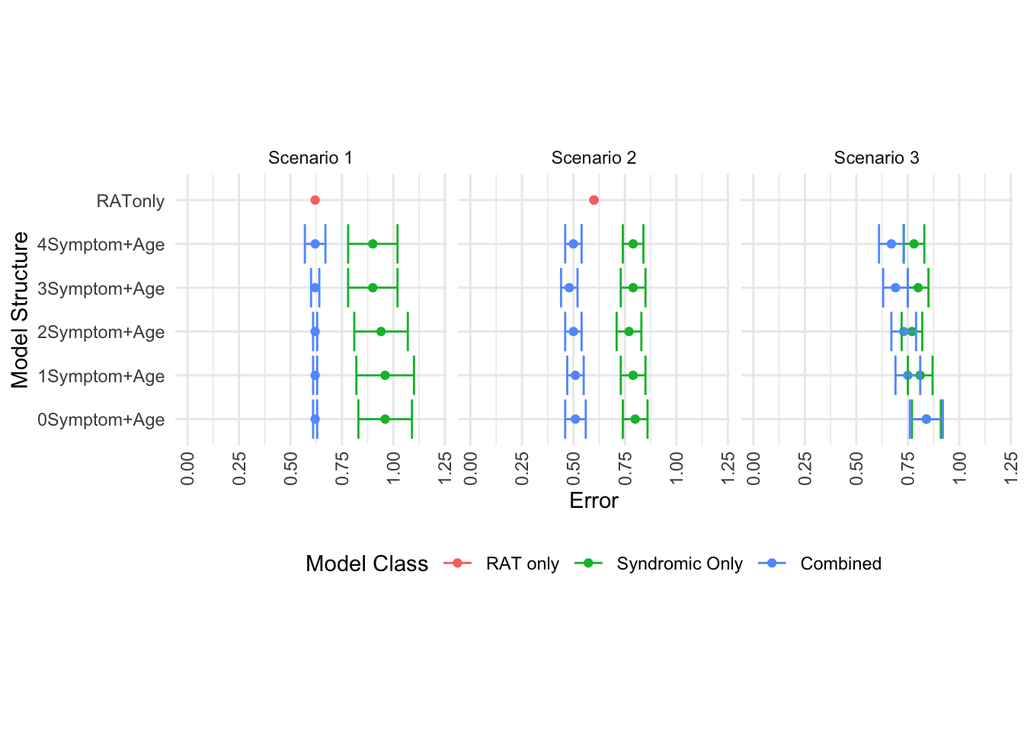

# Discussion

We have demonstrated that combining two imperfect diagnostics yields better prediction of COVID-19 status and greater flexibility than each diagnostic individually. These improvements are non-trivial in real-world settings like Bangladesh, where there are currently thousands of new cases being identified every day and the pandemic growth is accelerating meaning every missed case has a compounding effect. In the most relevant scenario, 2 where we try to keep the false negative rate low, the combined data model achieves 40 percentage points lower than the false negative rate of the RAT only model, and a 12 percentage points lower false positive rate than the syndromic only model. These are large performance gains for any diagnostic, although under the current situation will have a considerable impact on identifying both COVID-19 positive and negative patients. The pattern is similar in Scenario 3 with the predictive performance metrics showing that the combined model has equal or better performance across most potential scenarios. Furthermore, this boost is achieved with data that are already being collected in Bangladesh and other low- and middle- income countries. Outwith developing and rerunning the models presented in this paper, these improvements are essentially cost free and eminently scalable.

Syndromic identification and RATs are fast, inexpensive and can be performed at patients’ homes by minimally trained personnel. These imperfect detection methods have been developed as inexpensive alternatives to RT-PCR. While even the improvements described above will never allow these methods to compete with RT-PCR in terms of sensitivity and specificity, Rapid Antigen Testing and syndromic diagnosis also hold several further advantages. Unlike RT-PCR where patients have to go to designated testing centres, samples need to be taken by trained technologists and results take a day to a week to come back, both of the imperfect diagnostics can be delivered in the community with almost instant result delivery. This has several advantages. Firstly, increased accessibility by removing the need to travel for testing, thus reduces bias particularly against poorer, sicker and older people. Secondly, linked to cost, it is much easier to scale up testing when specialist training and expensive equipment and biosafety procedures are not required. Thirdly, it allows for assessment of an individual’s wellbeing in the home context, and thus facilitates tailoring interventions to where they are most needed.

The symptoms retained in the models may hint at the mechanism by which combining syndromic data and RAT results improves diagnosis. We have deliberately not emphasised the final symptoms chosen through model selection in this paper as we are focusing on prediction and classification for a unique sub-population: self-referring, symptomatic patients. We do, however, highlight that the symptoms retained in the final models for the syndromic-only and combined models are largely different (only one symptom appears in both lists). We propose that this is due to the fact that RAT is most effective during the first week of symptom onset, with much worse performance pre- and post- this period Muhi et al. (2021). These first-week symptoms are generally typical of viral pneumonias (Xu et al. 2020), and, indeed, when the RAT result is excluded from the model, the most important symptoms are typical of upper respiratory tract infections. However, when the RAT result is combined with syndromic data, the most important symptoms become much more eclectic. It is probable that these symptoms are either typical of later-stage COVID-19 or are less common presentations of the disease, possibly caused by co-infection or multimorbidities. Further research is needed to understand the mechanisms by which symptoms predict COVID-19 and by which RAT misses COVID-19. Of particular interest is whether individuals that are missed by RAT are less infectious, which could be explored by using Threshold Cycle (Ct) values from the RT-PCR to compare viral load with respect to prediction by the different methods (E. Albert et al. 2021). We note also that, as expected, age was retained in model selection. We were, however, surprised that gender was removed during model selection. Gender is thought to play a major role in infection risk Wolff et al. (2020). As we are looking to predict symptomatic COVID-19 in symptomatic individuals, generalised risk of infection is perhaps less predictive than expected, potentially due to the balancing of risk and burden (Joe et al. 2020).

We believe that the combined syndromic and rapid testing model represents the most promising approach to testing for COVID-19 in low- and middle- income countries at present. By taking a statistical modelling approach to case identification, we are able to update our diagnostic process in real time, allowing this method to readily adapt to new variants (or even new diseases) or new priorities for resource allocation. The modelling frameworks we have used are also sufficiently flexible to accommodate new data sources. Of particular interest are extensions to include the “pandemic context” in the model using space-time data. Furthermore, by using more sophisticated modelling structures it is possible to tune error rates to better reflect the local relative costs of false positives and false negatives. Naturally, these strengths have complementary limitations. Our models require updating in real-time and can only achieve good performance if the validation data is of high quality. Similarly, targeting error rates is only sensible if those rates properly reflect local conditions which is hard to do in practice. These limitations should be seriously considered but the alternatives for imperfect testing methods are diagnostics that cannot be tailored to local conditions at all (and, as such may perform worse than a method which is sub-optimally tailored to local conditions) or diagnostics which make these decisions implicitly and not explicitly. We believe that in choosing the latter these decisions are more readily challenged, researched and improved upon. We also emphasise the need for rigorous experimental design to ensure findings from the sample population are applicable to the target population and the need for further research into understanding error rate tradeoffs in applied settings.

The methodology we have outlined here is applicable to a wide range of diseases and settings across low- and middle-income countries. One of the biggest challenges in diagnosing and tracking many diseases in resource-limited settings is the low availability of access to gold-standard testing (such as RT-PCR in the case of COVID-19) and high error rate of alternative testing methods. In this paper, we have outlined a process for coupling a small number of gold-standard tests with formal statistical integration of alternative testing methods, to generate high quality diagnostic models. This process readily maps onto many other case identification problems, including the diagnosis of several neglected tropical diseases. For example, malaria (gold standard (GS) is also RT-PCR, imperfect methods (IM) include antigen tests, syndromic diagnosis and blood smears), schistosomiasis (GS: RT-PCR or autopsy; IM: Kato Katz egg counts, antibody detection) and rabies (GS: fluorescent antibody test; IM: light microscopy, differential diagnosis).

# Funding

The Bill and Melinda Gates Foundation funded work by FAO (INV-022851), and University of Glasgow reports funding from Wellcome (207569/Z/17/Z). The authors declare no competing interests.

Albert, Eliseo, Ignacio Torres, Felipe Bueno, Dixie Huntley, Estefanía Molla, Miguel Ángel Fernández-Fuentes, Mireia Martínez, et al. 2021. “Field Evaluation of a Rapid Antigen Test (Panbio™ COVID-19 Ag Rapid Test Device) for COVID-19 Diagnosis in Primary Healthcare Centres.” *Clinical Microbiology and Infection* 27 (3): 472–e7.

Albert, James H, and Siddhartha Chib. 1993. “Bayesian Analysis of Binary and Polychotomous Response Data.” *Journal of the American Statistical Association* 88 (422): 669–79.

Boum, Yap, Karl Njuwa Fai, Birgit Nikolay, Akenji Blaise Mboringong, Lisa M Bebell, Mark Ndifon, Aristide Abbah, et al. 2021. “Performance and Operational Feasibility of Antigen and Antibody Rapid Diagnostic Tests for COVID-19 in Symptomatic and Asymptomatic Patients in Cameroon: A Clinical, Prospective, Diagnostic Accuracy Study.” *The Lancet Infectious Diseases*.

Carpenter, Bob, Andrew Gelman, Matthew D Hoffman, Daniel Lee, Ben Goodrich, Michael Betancourt, Marcus Brubaker, Jiqiang Guo, Peter Li, and Allen Riddell. 2017. “Stan: A Probabilistic Programming Language.” *Journal of Statistical Software* 76 (1): 1–32.

Cash, Richard, and Vikram Patel. 2020. “Has COVID-19 Subverted Global Health?” *The Lancet* 395 (10238): 1687–88.

Chowdhury, Rajiv, Shammi Luhar, Nusrat Khan, Sohel Reza Choudhury, Imran Matin, and Oscar H Franco. 2020. “Long-Term Strategies to Control COVID-19 in Low and Middle-Income Countries: An Options Overview of Community-Based, Non-Pharmacological Interventions.” *European Journal of Epidemiology* 35 (8): 743–48.

Corman, Victor M, Olfert Landt, Marco Kaiser, Richard Molenkamp, Adam Meijer, Daniel KW Chu, Tobias Bleicker, et al. 2020. “Detection of 2019 Novel Coronavirus (2019-nCoV) by Real-Time RT-PCR.” *Eurosurveillance* 25 (3): 2000045.

Garry, Sylvia, Nada Abdelmagid, Louisa Baxter, Natalie Roberts, Olivier le Polain de Waroux, Sharif Ismail, Ruwan Ratnayake, Caroline Favas, Elizabeth Lewis, and Francesco Checchi. 2020. “Considerations for Planning COVID-19 Treatment Services in Humanitarian Responses.” *Conflict and Health* 14 (1): 1–11.

Gneiting, Tilmann, and Adrian E Raftery. 2007. “Strictly Proper Scoring Rules, Prediction, and Estimation.” *Journal of the American Statistical Association* 102 (477): 359–78.

Jin, Ying-Hui, Lin Cai, Zhen-Shun Cheng, Hong Cheng, Tong Deng, Yi-Pin Fan, Cheng Fang, et al. 2020. “A Rapid Advice Guideline for the Diagnosis and Treatment of 2019 Novel Coronavirus (2019-nCoV) Infected Pneumonia (Standard Version).” *Military Medical Research* 7 (1): 1–23.

Joe, William, Abhishek Kumar, Sunil Rajpal, US Mishra, and SV Subramanian. 2020. “Equal Risk, Unequal Burden? Gender Differentials in COVID-19 Mortality in India.” *Journal of Global Health Science* 2 (1).

Linares, Manuel, Ramón Pérez-Tanoira, Ana Carrero, Juan Romanyk, Felipe Pérez-García, Peña Gómez-Herruz, Teresa Arroyo, and Juan Cuadros. 2020. “Panbio Antigen Rapid Test Is Reliable to Diagnose SARS-CoV-2 Infection in the First 7 Days After the Onset of Symptoms.” *Journal of Clinical Virology* 133: 104659.

Mak, Gannon CK, Peter KC Cheng, Stephen SY Lau, Kitty KY Wong, CS Lau, Edman TK Lam, Rickjason CW Chan, and Dominic NC Tsang. 2020. “Evaluation of Rapid Antigen Test for Detection of SARS-CoV-2 Virus.” *Journal of Clinical Virology* 129: 104500.

Mayorga, Lía, Clara García Samartino, Gabriel Flores, Sofía Masuelli, María V Sánchez, Luis S Mayorga, and Cristián G Sánchez. 2020. “A Modelling Study Highlights the Power of Detecting and Isolating Asymptomatic or Very Mildly Affected Individuals for COVID-19 Epidemic Management.” *BMC Public Health* 20 (1): 1–11.

Menni, Cristina, Ana M Valdes, Maxim B Freidin, Carole H Sudre, Long H Nguyen, David A Drew, Sajaysurya Ganesh, et al. 2020. “Real-Time Tracking of Self-Reported Symptoms to Predict Potential COVID-19.” *Nature Medicine* 26 (7): 1037–40.

Muhi, Stephen, Nick Tayler, Tuyet Hoang, Susan A Ballard, Maryza Graham, Amanda Rojek, Jason C Kwong, et al. 2021. “Multi-Site Assessment of Rapid, Point-of-Care Antigen Testing for the Diagnosis of SARS-CoV-2 Infection in a Low-Prevalence Setting: A Validation and Implementation Study.” *The Lancet Regional Health-Western Pacific* 9: 100115.

Olalekan, Adesola, Bamidele Iwalokun, Oluwabukola M Akinloye, Olayiwola Popoola, Titilola A Samuel, and Oluyemi Akinloye. 2020. “COVID-19 Rapid Diagnostic Test Could Contain Transmission in Low-and Middle-Income Countries.” *African Journal of Laboratory Medicine* 9 (1): 1–8.

Sim, Jean Xiang Ying, Edwin Philip Conceicao, Liang En Wee, May Kyawt Aung, Sylvia Yi Wei Seow, Raymond Chee Yang Teo, Jia Qing Goh, et al. 2021. “Utilizing the Electronic Health Records to Create a Syndromic Staff Surveillance System During the COVID-19 Outbreak.” *American Journal of Infection Control* 49 (6): 685–89.

Surkova, Elena, Vladyslav Nikolayevskyy, and Francis Drobniewski. 2020. “False-Positive COVID-19 Results: Hidden Problems and Costs.” *The Lancet Respiratory Medicine* 8 (12): 1167–68.

Tahamtan, Alireza, and Abdollah Ardebili. 2020. “Real-Time RT-PCR in COVID-19 Detection: Issues Affecting the Results.” *Expert Review of Molecular Diagnostics* 20 (5): 453–54.

Undurraga, Eduardo A, Gerardo Chowell, and Kenji Mizumoto. 2021. “COVID-19 Case Fatality Risk by Age and Gender in a High Testing Setting in Latin America: Chile, March–August 2020.” *Infectious Diseases of Poverty* 10 (1): 1–11.

Vandenberg, Olivier, Delphine Martiny, Olivier Rochas, Alex van Belkum, and Zisis Kozlakidis. 2021. “Considerations for Diagnostic COVID-19 Tests.” *Nature Reviews Microbiology* 19 (3): 171–83.

Wenham, Clare, Julia Smith, and Rosemary Morgan. 2020. “COVID-19: The Gendered Impacts of the Outbreak.” *The Lancet* 395 (10227): 846–48.

West, Colin P, Victor M Montori, and Priya Sampathkumar. 2020. “COVID-19 Testing: The Threat of False-Negative Results.” In *Mayo Clinic Proceedings*, 95:1127–29. 6. Elsevier.

Wolff, Dominik, Sarah Nee, Natalie Sandy Hickey, and Michael Marschollek. 2020. “Risk Factors for Covid-19 Severity and Fatality: A Structured Literature Review.” *Infection*, 1–14.

Xu, Tianmin, Cong Chen, Zhen Zhu, Manman Cui, Chunhua Chen, Hong Dai, and Yuan Xue. 2020. “Clinical Features and Dynamics of Viral Load in Imported and Non-Imported Patients with COVID-19.” *International Journal of Infectious Diseases* 94: 68–71.